# 01 - Introduction to R

Biostatistics 735 — Machine Learning in Public Health

Author

Alexander McLain

Published

August 20, 2026

# 1 Overview

By the end of this document you will be able to:

- Install and load R packages
- Set the working directory directly and with `this.path`
- Read CSV, Excel, and other common file formats into R
- Recognize the main variable types in R and convert between them
- Manipulate and transform data using core `dplyr` verbs
- Combine data frames using mutating and filtering joins
- Build exploratory and publication-ready plots with `ggplot2`
- Create and render a Quarto document

# 2 Packages

Base R is powerful, but most of what we will do in this course uses **packages** — collections of functions contributed by the R community. There are over 20,000 available.

**Install once** (downloads to your machine):

```r
install.packages("tidyverse")
```

**Load at the start of every session** (makes functions available):

```r
library(tidyverse)
```

**Important**

`install.packages()` and `library()` do different things. Installing downloads the package; loading activates it. You only install once, but you load every session.

Also: use straight quotes (`"tidyverse"`), not curly/smart quotes. Smart quotes will cause an error.

`tidyverse` loads several packages at once:

| Package | Purpose |
| --- | --- |
| `ggplot2` | Data visualization |
| `dplyr` | Data manipulation |
| `tidyr` | Reshaping data |
| `readr` | Reading/writing files |
| `stringr` | Working with text |
| `forcats` | Working with categorical variables |

We will use all of these throughout the course. Additional packages used in this document:

```r
install.packages(c("nycflights13", "janitor", "ggrepel", "haven", "this.path"))
```

# 3 Working Directory

## 3.1 Setting It Directly

R looks for files relative to the **working directory**. Check yours with `getwd()`:

```r
getwd()
```

```
[1] "/Users/mclainfamily/Library/CloudStorage/OneDrive2-UniversityofSouthCarolina/Teaching/735/Bios_735/Class-Material/Examples"
```

You can set it manually with `setwd()`:

```r
setwd("/Users/yourname/Documents/my-project")
```

Hard-coded paths like this break on other people’s machines, so they should be avoided whenever possible.

## 3.2 Using `this.path`

Rather than hard-coding a full file path, use `this.path` to set the working directory to wherever the script lives. Note, `rstudioapi` only works inside of RStudio and can give error messages when used with `.qmd` files (and in other situations). `this.path` is usually safer.

```r
library(rstudioapi)
this.dir <- dirname(rstudioapi::getSourceEditorContext()$path)
setwd(this.dir)

library(this.path)
this.dir <- this.dir()
setwd(this.dir)
```

Then reference files with short relative paths: `"data/myfile.csv"` rather than `"/Users/yourname/Documents/.../myfile.csv"`.

You can use `"../data/framingham.csv"` to tell R to go back one folder, find the data folder, and then look for `framingham.csv`.

**Tip**

**Windows users:** File paths use `\` in Windows Explorer, but R requires `/` or `\\`. Copy a path from Explorer and replace each `\` with `/` before using it in R.

# 4 Reading in Data

## 4.1 Key Terms

Before reading data into R, three concepts matter:

- **Header:** The first row of a file is usually variable names. R needs to know whether to treat it as names or as data values.
- **Delimiter:** The character that separates entries in each row (comma in `.csv`, tab in `.tsv`, etc.). R uses this to know where one value ends and the next begins.
- **Missing value:** How your file represents missingness. R recognizes `NA`, but files often use `.`, `""`, `N/A`, `999`, or other codes that need to be declared.

## 4.2 Reading CSV Files with `readr`

`readr` is the tidyverse package for reading rectangular data. The most common functions:

| Function | Reads |
| --- | --- |
| `read_csv()` | Comma-separated (`.csv`) |
| `read_csv2()` | Semicolon-separated (common in Europe) |
| `read_tsv()` | Tab-separated |
| `read_delim()` | Any delimiter you specify |

All have the same interface — once you know `read_csv()` the rest are trivial.

```r
library(this.path)
setwd(this.dir())
framingham <- read_csv("framingham.csv")
```

When you run `read_csv()` it prints a message showing the number of rows and columns, the delimiter used, and how each column was parsed. This is useful for catching problems early.

### 4.2.1 Common Arguments

**Skipping rows** — useful when files have metadata at the top:

```r
read_csv("The first line of metadata
  The second line of metadata
  x,y,z
  1,2,3", skip = 2)
```

```
# A tibble: 1 × 3
      x     y     z
  <dbl> <dbl> <dbl>
1     1     2     3
```

**No column names** — tell R to generate them:

```r
read_csv("1,2,3
         4,5,6", col_names = FALSE)
```

```
# A tibble: 2 × 3
     X1    X2    X3
  <dbl> <dbl> <dbl>
1     1     2     3
2     4     5     6
```

**Declare missing value codes** — files often use `.` or `N/A` instead of `NA`:

```r
read_csv("a,b,c
         1,2,.", na = ".")
```

```
# A tibble: 1 × 3
      a     b c
  <dbl> <dbl> <lgl>
1     1     2 NA
```

### 4.2.2 Post-Import Cleaning

After reading data in, two immediate tasks often arise:

**1. Fix column names with spaces.** Column names with spaces require backtick quoting (`` `Full Name` ``) which is error-prone. Use `janitor::clean_names()` to convert everything to snake_case automatically:

```r
library(janitor)
x <- data.frame(caseID = 1, DOB = 2, Other = 3)
x |>
  clean_names()
```

```
  case_id dob other
1       1   2     3
```

Or rename specific columns with `rename()`:

```r
x |> rename(case_id = `caseID`, dob = DOB, other = Other)
```

```
  case_id dob other
1       1   2     3
```

**2. Fix variable types.** `read_csv()` guesses column types from the data. Always check with `str()` and correct anything that was misread (e.g., a numeric column read as character because of a stray word like `"five"`).

## 4.3 Reading Excel Files

Use `readxl::read_excel()`. You can specify which sheet to read:

```r
library(readxl)
data_xl <- read_excel("data/myfile.xlsx", sheet = "data")
dict_xl <- read_excel("data/myfile.xlsx", sheet = "dictionary")
```

The same arguments apply: `col_names`, `na`, `skip`.

## 4.4 Writing Data

```r
write_csv(framingham, "framingham_clean.csv")
```

**Note**

**Important:** When you write a tibble to CSV and read it back, factor levels and other type information are lost — the file only stores plain text. If you need to preserve types across sessions, use `saveRDS()` / `readRDS()` to save as an R binary file instead.

## 4.5 Other Formats

The `haven` package reads SAS (`.sas7bdat`), Stata (`.dta`), and SPSS (`.sav`) files with the same interface:

```r
library(haven)
spss_data  <- read_sav("data/myfile.sav")
sas_data   <- read_sas("data/myfile.sas7bdat")
stata_data <- read_dta("data/myfile.dta")
```

SPSS and Stata files often carry variable labels and value labels that `haven` preserves as attributes — useful when you are handed someone else’s data and need to understand the coding.

**Tip**

You can read in SAS data, you can even write SAS data (using `write_sas`), but SAS data exported from R will not properly be read into SAS. Exported SPSS (`write_sav`) and Stata (`write_dta`) files can be read into their respective software programs.

# 5 Variable Types (Brief)

The type of a variable determines what operations you can do with it and how R and statistical functions will treat it. Getting variable types right is one of the most important — and most commonly skipped — steps in data preparation.

We will use the `flights` dataset from the `nycflights13` package throughout.

```r
library(nycflights13)
flights
```

```
# A tibble: 336,776 × 19
    year month   day dep_time sched_dep_time dep_delay arr_time sched_arr_time
   <int> <int> <int>    <int>          <int>     <dbl>    <int>          <int>
 1  2013     1     1      517            515         2      830            819
 2  2013     1     1      533            529         4      850            830
 3  2013     1     1      542            540         2      923            850
 4  2013     1     1      544            545        -1     1004           1022
 5  2013     1     1      554            600        -6      812            837
 6  2013     1     1      554            558        -4      740            728
 7  2013     1     1      555            600        -5      913            854
 8  2013     1     1      557            600        -3      709            723
 9  2013     1     1      557            600        -3      838            846
10  2013     1     1      558            600        -2      753            745
# ℹ 336,766 more rows
# ℹ 11 more variables: arr_delay <dbl>, carrier <chr>, flight <int>,
#   tailnum <chr>, origin <chr>, dest <chr>, air_time <dbl>, distance <dbl>,
#   hour <dbl>, minute <dbl>, time_hour <dttm>
```

The abbreviations under each column name tell you the type:

| Abbreviation | Type | Example |
| --- | --- | --- |
| `<int>` | Integer | `year`, `month`, `day` |
| `<dbl>` | Double (numeric, decimal) | `dep_delay`, `air_time` |
| `<chr>` | Character (string) | `carrier`, `origin` |
| `<lgl>` | Logical (TRUE/FALSE) | e.g., `is_delayed` |
| `<fct>` | Factor (categorical with levels) | e.g., severity grades |
| `<dttm>` | Date-time | `time_hour` |

## 5.1 Numeric Variables (`<dbl>`, `<int>`)

Numeric variables represent measured quantities. Arithmetic and summary functions apply directly.

```r
mean(flights$dep_delay, na.rm = TRUE)
```

```
[1] 12.63907
```

```r
sd(flights$dep_delay, na.rm = TRUE)
```

```
[1] 40.21006
```

```r
range(flights$air_time, na.rm = TRUE)
```

```
[1]  20 695
```

**Note**

`na.rm = TRUE` tells R to ignore missing values when computing the summary. Without it, a single `NA` in the vector will return `NA` for the whole calculation.

## 5.2 Character Variables (`<chr>`)

Character variables (strings) hold text. They cannot be used in arithmetic but can be searched, split, and recoded.

```r
unique(flights$carrier)
```

```
 [1] "UA" "AA" "B6" "DL" "EV" "MQ" "US" "WN" "VX" "FL" "AS" "9E" "F9" "HA" "YV"
[16] "OO"
```

```r
table(flights$carrier)
```

```
   9E    AA    AS    B6    DL    EV    F9    FL    HA    MQ    OO    UA    US
18460 32729   714 54635 48110 54173   685  3260   342 26397    32 58665 20536
   VX    WN    YV
 5162 12275   601
```

## 5.3 Logical Variables (`<lgl>`)

Logicals are `TRUE` or `FALSE`. They arise naturally from comparisons and are useful for filtering and counting. `sum()` and `mean()` treat `TRUE` as 1 and `FALSE` as 0, so you can count and compute proportions easily:

```r
sum(flights$arr_delay > 0, na.rm = TRUE)
```

```
[1] 133004
```

```r
mean(flights$arr_delay > 0, na.rm = TRUE) * 100
```

```
[1] 40.63101
```

## 5.4 Factors (`<fct>`)

Factors represent **categorical variables with a fixed set of levels**. They are essential in statistical modeling — a factor in a regression model is handled as a categorical predictor (with a reference level), while a character variable or numeric code is not.

```r
severity <- factor(c("mild", "severe", "moderate", "mild", "severe"),
                   levels = c("mild", "moderate", "severe"))
severity
```

```
[1] mild     severe   moderate mild     severe
Levels: mild moderate severe
```

```r
levels(severity)
```

```
[1] "mild"     "moderate" "severe"
```

```r
table(severity)
```

```
severity
    mild moderate   severe
       2        1        2
```

**Important**

**When does this matter for you?** If you code a categorical variable as a number (e.g., 1 = mild, 2 = moderate, 3 = severe) and put it in a model without converting it to a factor, R will treat it as a continuous variable and fit a single slope. This is almost never what you want. Always check whether your grouping variables are stored as factors. **This is one of the most common errors when running models in R.**

The first level is the reference level. To change it use `relevel` (important for model interpretation):

```r
severity_reref <- relevel(severity, ref = "moderate")
levels(severity_reref)
```

```
[1] "moderate" "mild"     "severe"
```

`fct_recode()` lets you rename levels; `fct_collapse()` merges them:

```r
severity_recoded <- fct_recode(severity,
  "Grade 1" = "mild",
  "Grade 2" = "moderate",
  "Grade 3" = "severe"
)
levels(severity_recoded)
```

```
[1] "Grade 1" "Grade 2" "Grade 3"
```

```r
fct_collapse(severity,
  "low"  = "mild",
  "high" = c("moderate", "severe")
)
```

```
[1] low  high high low  high
Levels: low high
```

# 6 Data Transformations with dplyr

`dplyr` is the workhorse package for data manipulation. Its functions are called **verbs** because each one does one thing clearly. We will cover the ones you will use in almost every analysis.

## 6.1 The Pipe

The pipe (`|>`) passes the output of one function as the first argument of the next. Read it as “then”:

```r
flights |>           # start with flights, then
  filter(...) |>     # keep certain rows, then
  mutate(...) |>     # create new columns, then
  summarize(...)     # collapse to a summary
```

You may also see `%>%` from the `magrittr` package — it behaves identically for our purposes.

## 6.2 Filtering Rows: `filter()`

Keep rows that satisfy a condition:

```r
flights |>
  filter(arr_delay > 120)
```

```
# A tibble: 10,034 × 19
    year month   day dep_time sched_dep_time dep_delay arr_time sched_arr_time
   <int> <int> <int>    <int>          <int>     <dbl>    <int>          <int>
 1  2013     1     1      811            630       101     1047            830
 2  2013     1     1      848           1835       853     1001           1950
 3  2013     1     1      957            733       144     1056            853
 4  2013     1     1     1114            900       134     1447           1222
 5  2013     1     1     1505           1310       115     1638           1431
 6  2013     1     1     1525           1340       105     1831           1626
 7  2013     1     1     1549           1445        64     1912           1656
 8  2013     1     1     1558           1359       119     1718           1515
 9  2013     1     1     1732           1630        62     2028           1825
10  2013     1     1     1803           1620       103     2008           1750
# ℹ 10,024 more rows
# ℹ 11 more variables: arr_delay <dbl>, carrier <chr>, flight <int>,
#   tailnum <chr>, origin <chr>, dest <chr>, air_time <dbl>, distance <dbl>,
#   hour <dbl>, minute <dbl>, time_hour <dttm>
```

```r
flights |>
  filter(month == 1 &
           carrier %in% c("UA", "AA")
         )
```

```
# A tibble: 7,431 × 19
    year month   day dep_time sched_dep_time dep_delay arr_time sched_arr_time
   <int> <int> <int>    <int>          <int>     <dbl>    <int>          <int>
 1  2013     1     1      517            515         2      830            819
 2  2013     1     1      533            529         4      850            830
 3  2013     1     1      542            540         2      923            850
 4  2013     1     1      554            558        -4      740            728
 5  2013     1     1      558            600        -2      753            745
 6  2013     1     1      558            600        -2      924            917
 7  2013     1     1      558            600        -2      923            937
 8  2013     1     1      559            600        -1      941            910
 9  2013     1     1      559            600        -1      854            902
10  2013     1     1      606            610        -4      858            910
# ℹ 7,421 more rows
# ℹ 11 more variables: arr_delay <dbl>, carrier <chr>, flight <int>,
#   tailnum <chr>, origin <chr>, dest <chr>, air_time <dbl>, distance <dbl>,
#   hour <dbl>, minute <dbl>, time_hour <dttm>
```

Common operators: `>`, `>=`, `<`, `<=`, `==`, `!=`, `%in%`, `is.na()`.

**Note**

`=` assigns a value; `==` tests for equality. Using `=` inside `filter()` is one of the most common beginner errors in R.

## 6.3 Selecting and Renaming Columns: `select()` and `rename()`

```r
flights |>
  select(year, month, day, carrier, dep_delay, arr_delay)
```

```
# A tibble: 336,776 × 6
    year month   day carrier dep_delay arr_delay
   <int> <int> <int> <chr>       <dbl>     <dbl>
 1  2013     1     1 UA              2        11
 2  2013     1     1 UA              4        20
 3  2013     1     1 AA              2        33
 4  2013     1     1 B6             -1       -18
 5  2013     1     1 DL             -6       -25
 6  2013     1     1 UA             -4        12
 7  2013     1     1 B6             -5        19
 8  2013     1     1 EV             -3       -14
 9  2013     1     1 B6             -3        -8
10  2013     1     1 AA             -2         8
# ℹ 336,766 more rows
```

```r
flights |>
  rename(tail_number = tailnum) |>
  select(tail_number, carrier)
```

```
# A tibble: 336,776 × 2
   tail_number carrier
   <chr>       <chr>
 1 N14228      UA
 2 N24211      UA
 3 N619AA      AA
 4 N804JB      B6
 5 N668DN      DL
 6 N39463      UA
 7 N516JB      B6
 8 N829AS      EV
 9 N593JB      B6
10 N3ALAA      AA
# ℹ 336,766 more rows
```

Useful helpers inside `select()`: `starts_with()`, `ends_with()`, `contains()`, `where(is.numeric)`.

```r
flights |>
  select(contains("time"))
```

```
# A tibble: 336,776 × 6
   dep_time sched_dep_time arr_time sched_arr_time air_time time_hour
      <int>          <int>    <int>          <int>    <dbl> <dttm>
 1      517            515      830            819      227 2013-01-01 05:00:00
 2      533            529      850            830      227 2013-01-01 05:00:00
 3      542            540      923            850      160 2013-01-01 05:00:00
 4      544            545     1004           1022      183 2013-01-01 05:00:00
 5      554            600      812            837      116 2013-01-01 06:00:00
 6      554            558      740            728      150 2013-01-01 05:00:00
 7      555            600      913            854      158 2013-01-01 06:00:00
 8      557            600      709            723       53 2013-01-01 06:00:00
 9      557            600      838            846      140 2013-01-01 06:00:00
10      558            600      753            745      138 2013-01-01 06:00:00
# ℹ 336,766 more rows
```

## 6.4 Creating and Modifying Columns: `mutate()`

`mutate()` adds new columns or overwrites existing ones:

```r
flights |>
  mutate(
    gain       = dep_delay - arr_delay,
    speed_mph  = distance / air_time * 60,
    late       = arr_delay > 0
  ) |>
  select(carrier, gain, speed_mph, late)
```

```
# A tibble: 336,776 × 4
   carrier  gain speed_mph late
   <chr>   <dbl>     <dbl> <lgl>
 1 UA         -9      370. TRUE
 2 UA        -16      374. TRUE
 3 AA        -31      408. TRUE
 4 B6         17      517. FALSE
 5 DL         19      394. FALSE
 6 UA        -16      288. TRUE
 7 B6        -24      404. TRUE
 8 EV         11      259. FALSE
 9 B6          5      405. FALSE
10 AA        -10      319. TRUE
# ℹ 336,766 more rows
```

`mutate()` is also where you will do type conversions:

```r
flights |>
  mutate(
    month_fct = factor(month,
                       levels = 1:12,
                       labels = month.abb)
  ) |>
  count(month_fct)
```

```
# A tibble: 12 × 2
   month_fct     n
   <fct>     <int>
 1 Jan       27004
 2 Feb       24951
 3 Mar       28834
 4 Apr       28330
 5 May       28796
 6 Jun       28243
 7 Jul       29425
 8 Aug       29327
 9 Sep       27574
10 Oct       28889
11 Nov       27268
12 Dec       28135
```

## 6.5 Recoding Variables: `if_else()` and `case_when()`

`if_else()` handles a simple two-way recode:

```r
flights |>
  mutate(long_flight = if_else(air_time > 300, "Long", "Short")) |>
  count(long_flight)
```

```
# A tibble: 3 × 2
  long_flight      n
  <chr>        <int>
1 Long         43654
2 Short       283692
3 <NA>          9430
```

`case_when()` handles three or more conditions. Each condition is written as `condition ~ value`, and `.default` catches anything not matched:

```r
flights |>
  mutate(
    delay_category = case_when(
      dep_delay <= 0   ~ "On time or early",
      dep_delay <= 30  ~ "Minor delay (<= 30 min)",
      dep_delay <= 120 ~ "Moderate delay (31-120 min)",
      .default         = "Major delay (> 120 min)"
    )
  ) |>
  count(delay_category)
```

```
# A tibble: 4 × 2
  delay_category                   n
  <chr>                        <int>
1 Major delay (> 120 min)      17978
2 Minor delay (<= 30 min)      80141
3 Moderate delay (31-120 min)  38568
4 On time or early            200089
```

Conditions are evaluated top to bottom — the first match wins.

## 6.6 Sorting: `arrange()`

```r
flights |>
  arrange(desc(dep_delay)) |>
  select(carrier, origin, dest, dep_delay)
```

```
# A tibble: 336,776 × 4
   carrier origin dest  dep_delay
   <chr>   <chr>  <chr>     <dbl>
 1 HA      JFK    HNL        1301
 2 MQ      JFK    CMH        1137
 3 MQ      EWR    ORD        1126
 4 AA      JFK    SFO        1014
 5 MQ      JFK    CVG        1005
 6 DL      JFK    TPA         960
 7 DL      LGA    MSP         911
 8 DL      JFK    PDX         899
 9 DL      LGA    ATL         898
10 AA      EWR    MIA         896
# ℹ 336,766 more rows
```

## 6.7 Grouped Summaries: `group_by()` + `summarize()`

This combination is how you compute group-level statistics:

```r
flights |>
  group_by(carrier) |>
  summarize(
    mean_delay = mean(arr_delay, na.rm = TRUE),
    n_flights  = n()
  ) |>
  arrange(desc(mean_delay))
```

```
# A tibble: 16 × 3
   carrier mean_delay n_flights
   <chr>        <dbl>     <int>
 1 F9          21.9         685
 2 FL          20.1        3260
 3 EV          15.8       54173
 4 YV          15.6         601
 5 OO          11.9          32
 6 MQ          10.8       26397
 7 WN           9.65      12275
 8 B6           9.46      54635
 9 9E           7.38      18460
10 UA           3.56      58665
11 US           2.13      20536
12 VX           1.76       5162
13 DL           1.64      48110
14 AA           0.364     32729
15 HA          -6.92        342
16 AS          -9.93        714
```

**Note**

Always include `na.rm = TRUE` inside summary functions like `mean()`, `sd()`, and `median()`. Missing values in the input will return `NA` for the whole summary otherwise.

Multiple grouping variables:

```r
flights |>
  group_by(origin, carrier) |>
  summarize(
    mean_delay = mean(arr_delay, na.rm = TRUE),
    n          = n(),
    .groups    = "drop"
  )
```

```
# A tibble: 35 × 4
   origin carrier mean_delay     n
   <chr>  <chr>        <dbl> <int>
 1 EWR    9E           1.62   1268
 2 EWR    AA           0.978  3487
 3 EWR    AS          -9.93    714
 4 EWR    B6           9.39   6557
 5 EWR    DL           8.78   4342
 6 EWR    EV          17.0   43939
 7 EWR    MQ          16.3    2276
 8 EWR    OO          21.5       6
 9 EWR    UA           3.48  46087
10 EWR    US           0.977  4405
# ℹ 25 more rows
```

## 6.8 Putting It Together: A Pipeline

Compute the on-time arrival rate by carrier for flights longer than 500 miles, keeping only carriers with at least 1,000 such flights:

```r
flights |>
  filter(distance > 500) |>
  mutate(on_time = arr_delay <= 0) |>
  group_by(carrier) |>
  summarize(
    n           = n(),
    pct_on_time = mean(on_time, na.rm = TRUE) * 100
  ) |>
  filter(n >= 1000) |>
  arrange(desc(pct_on_time))
```

```
# A tibble: 11 × 3
   carrier     n pct_on_time
   <chr>   <int>       <dbl>
 1 AA      31274        66.3
 2 VX       5162        65.9
 3 DL      46231        65.4
 4 US      10903        61.9
 5 UA      53418        61.1
 6 9E       9531        61.0
 7 WN      12067        55.8
 8 B6      40132        54.3
 9 MQ      13763        50.8
10 EV      29544        49.9
11 FL       2396        38.1
```

# 7 Joining Data

## 7.1 Why Join?

It is rare that all the information you need lives in a single data frame. Relational data — data spread across multiple linked tables — is the norm in practice. Joins let you combine them.

We will use the `nycflights13` package, which has five related tables:

- `flights`: every flight departing NYC in 2013
- `airlines`: carrier codes and full names
- `airports`: airport codes and metadata
- `planes`: plane metadata by tail number
- `weather`: hourly weather at each NYC airport

## 7.2 Keys

A **primary key** uniquely identifies each row in a table. A **foreign key** is the matching variable in another table that refers back to the primary key.

```r
airlines  # primary key: carrier
```

```
# A tibble: 16 × 2
   carrier name
   <chr>   <chr>
 1 9E      Endeavor Air Inc.
 2 AA      American Airlines Inc.
 3 AS      Alaska Airlines Inc.
 4 B6      JetBlue Airways
 5 DL      Delta Air Lines Inc.
 6 EV      ExpressJet Airlines Inc.
 7 F9      Frontier Airlines Inc.
 8 FL      AirTran Airways Corporation
 9 HA      Hawaiian Airlines Inc.
10 MQ      Envoy Air
11 OO      SkyWest Airlines Inc.
12 UA      United Air Lines Inc.
13 US      US Airways Inc.
14 VX      Virgin America
15 WN      Southwest Airlines Co.
16 YV      Mesa Airlines Inc.
```

```r
airports  # primary key: faa
```

```
# A tibble: 1,458 × 8
   faa   name                             lat    lon   alt    tz dst   tzone
   <chr> <chr>                          <dbl>  <dbl> <dbl> <dbl> <chr> <chr>
 1 04G   Lansdowne Airport               41.1  -80.6  1044    -5 A     America/…
 2 06A   Moton Field Municipal Airport   32.5  -85.7   264    -6 A     America/…
 3 06C   Schaumburg Regional             42.0  -88.1   801    -6 A     America/…
 4 06N   Randall Airport                 41.4  -74.4   523    -5 A     America/…
 5 09J   Jekyll Island Airport           31.1  -81.4    11    -5 A     America/…
 6 0A9   Elizabethton Municipal Airport  36.4  -82.2  1593    -5 A     America/…
 7 0G6   Williams County Airport         41.5  -84.5   730    -5 A     America/…
 8 0G7   Finger Lakes Regional Airport   42.9  -76.8   492    -5 A     America/…
 9 0P2   Shoestring Aviation Airfield    39.8  -76.6  1000    -5 U     America/…
10 0S9   Jefferson County Intl           48.1 -123.    108    -8 A     America/…
# ℹ 1,448 more rows
```

```r
planes    # primary key: tailnum
```

```
# A tibble: 3,322 × 9
   tailnum  year type              manufacturer model engines seats speed engine
   <chr>   <int> <chr>             <chr>        <chr>   <int> <int> <int> <chr>
 1 N10156   2004 Fixed wing multi… EMBRAER      EMB-…       2    55    NA Turbo…
 2 N102UW   1998 Fixed wing multi… AIRBUS INDU… A320…       2   182    NA Turbo…
 3 N103US   1999 Fixed wing multi… AIRBUS INDU… A320…       2   182    NA Turbo…
 4 N104UW   1999 Fixed wing multi… AIRBUS INDU… A320…       2   182    NA Turbo…
 5 N10575   2002 Fixed wing multi… EMBRAER      EMB-…       2    55    NA Turbo…
 6 N105UW   1999 Fixed wing multi… AIRBUS INDU… A320…       2   182    NA Turbo…
 7 N107US   1999 Fixed wing multi… AIRBUS INDU… A320…       2   182    NA Turbo…
 8 N108UW   1999 Fixed wing multi… AIRBUS INDU… A320…       2   182    NA Turbo…
 9 N109UW   1999 Fixed wing multi… AIRBUS INDU… A320…       2   182    NA Turbo…
10 N110UW   1999 Fixed wing multi… AIRBUS INDU… A320…       2   182    NA Turbo…
# ℹ 3,312 more rows
```

Always verify that a claimed primary key actually uniquely identifies rows:

```r
planes |>
  count(tailnum) |>
  filter(n > 1)
```

```
# A tibble: 0 × 2
# ℹ 2 variables: tailnum <chr>, n <int>
```

```r
weather |>
  count(origin, time_hour) |>
  filter(n > 1)
```

```
# A tibble: 0 × 3
# ℹ 3 variables: origin <chr>, time_hour <dttm>, n <int>
```

Empty results confirm both keys are valid.

## 7.3 Mutating Joins

A **mutating join** adds columns from one table to another by matching on a key.

```r
flights2 <- flights |>
  select(year, time_hour, origin, dest, tailnum, carrier)
flights2
```

```
# A tibble: 336,776 × 6
    year time_hour           origin dest  tailnum carrier
   <int> <dttm>              <chr>  <chr> <chr>   <chr>
 1  2013 2013-01-01 05:00:00 EWR    IAH   N14228  UA
 2  2013 2013-01-01 05:00:00 LGA    IAH   N24211  UA
 3  2013 2013-01-01 05:00:00 JFK    MIA   N619AA  AA
 4  2013 2013-01-01 05:00:00 JFK    BQN   N804JB  B6
 5  2013 2013-01-01 06:00:00 LGA    ATL   N668DN  DL
 6  2013 2013-01-01 05:00:00 EWR    ORD   N39463  UA
 7  2013 2013-01-01 06:00:00 EWR    FLL   N516JB  B6
 8  2013 2013-01-01 06:00:00 LGA    IAD   N829AS  EV
 9  2013 2013-01-01 06:00:00 JFK    MCO   N593JB  B6
10  2013 2013-01-01 06:00:00 LGA    ORD   N3ALAA  AA
# ℹ 336,766 more rows
```

### 7.3.1 `left_join()` — the join you will use 90% of the time

`left_join(x, y)` keeps every row in `x` and fills in matching columns from `y`. Rows in `x` with no match in `y` get `NA` for the new columns.

```r
flights2 |>
  left_join(airlines)
```

```
# A tibble: 336,776 × 7
    year time_hour           origin dest  tailnum carrier name
   <int> <dttm>              <chr>  <chr> <chr>   <chr>   <chr>
 1  2013 2013-01-01 05:00:00 EWR    IAH   N14228  UA      United Air Lines Inc.
 2  2013 2013-01-01 05:00:00 LGA    IAH   N24211  UA      United Air Lines Inc.
 3  2013 2013-01-01 05:00:00 JFK    MIA   N619AA  AA      American Airlines Inc.
 4  2013 2013-01-01 05:00:00 JFK    BQN   N804JB  B6      JetBlue Airways
 5  2013 2013-01-01 06:00:00 LGA    ATL   N668DN  DL      Delta Air Lines Inc.
 6  2013 2013-01-01 05:00:00 EWR    ORD   N39463  UA      United Air Lines Inc.
 7  2013 2013-01-01 06:00:00 EWR    FLL   N516JB  B6      JetBlue Airways
 8  2013 2013-01-01 06:00:00 LGA    IAD   N829AS  EV      ExpressJet Airlines I…
 9  2013 2013-01-01 06:00:00 JFK    MCO   N593JB  B6      JetBlue Airways
10  2013 2013-01-01 06:00:00 LGA    ORD   N3ALAA  AA      American Airlines Inc.
# ℹ 336,766 more rows
```

```r
flights2 |>
  left_join(weather |> select(origin, time_hour, temp, wind_speed))
```

```
# A tibble: 336,776 × 8
    year time_hour           origin dest  tailnum carrier  temp wind_speed
   <int> <dttm>              <chr>  <chr> <chr>   <chr>   <dbl>      <dbl>
 1  2013 2013-01-01 05:00:00 EWR    IAH   N14228  UA       39.0       12.7
 2  2013 2013-01-01 05:00:00 LGA    IAH   N24211  UA       39.9       15.0
 3  2013 2013-01-01 05:00:00 JFK    MIA   N619AA  AA       39.0       15.0
 4  2013 2013-01-01 05:00:00 JFK    BQN   N804JB  B6       39.0       15.0
 5  2013 2013-01-01 06:00:00 LGA    ATL   N668DN  DL       39.9       16.1
 6  2013 2013-01-01 05:00:00 EWR    ORD   N39463  UA       39.0       12.7
 7  2013 2013-01-01 06:00:00 EWR    FLL   N516JB  B6       37.9       11.5
 8  2013 2013-01-01 06:00:00 LGA    IAD   N829AS  EV       39.9       16.1
 9  2013 2013-01-01 06:00:00 JFK    MCO   N593JB  B6       37.9       13.8
10  2013 2013-01-01 06:00:00 LGA    ORD   N3ALAA  AA       39.9       16.1
# ℹ 336,766 more rows
```

```r
flights2 |>
  left_join(planes |> select(tailnum, type, engines, seats))
```

```
# A tibble: 336,776 × 9
    year time_hour           origin dest  tailnum carrier type     engines seats
   <int> <dttm>              <chr>  <chr> <chr>   <chr>   <chr>      <int> <int>
 1  2013 2013-01-01 05:00:00 EWR    IAH   N14228  UA      Fixed w…       2   149
 2  2013 2013-01-01 05:00:00 LGA    IAH   N24211  UA      Fixed w…       2   149
 3  2013 2013-01-01 05:00:00 JFK    MIA   N619AA  AA      Fixed w…       2   178
 4  2013 2013-01-01 05:00:00 JFK    BQN   N804JB  B6      Fixed w…       2   200
 5  2013 2013-01-01 06:00:00 LGA    ATL   N668DN  DL      Fixed w…       2   178
 6  2013 2013-01-01 05:00:00 EWR    ORD   N39463  UA      Fixed w…       2   191
 7  2013 2013-01-01 06:00:00 EWR    FLL   N516JB  B6      Fixed w…       2   200
 8  2013 2013-01-01 06:00:00 LGA    IAD   N829AS  EV      Fixed w…       2    55
 9  2013 2013-01-01 06:00:00 JFK    MCO   N593JB  B6      Fixed w…       2   200
10  2013 2013-01-01 06:00:00 LGA    ORD   N3ALAA  AA      <NA>          NA    NA
# ℹ 336,766 more rows
```

**Important**

**Why `left_join()` almost always?** Because it preserves every row in your primary dataset. You will not silently lose observations the way `inner_join()` can. If a join key is missing from `y`, you get `NA` — which is visible and diagnosable. If `inner_join()` drops rows, you may not notice.

### 7.3.2 Specifying the Join Key

By default, `left_join()` joins on all columns with matching names. When key names differ across tables, use `by`:

```r
flights2 |>
  left_join(airports, by = c("dest" = "faa"))
```

```
# A tibble: 336,776 × 13
    year time_hour           origin dest  tailnum carrier name         lat   lon
   <int> <dttm>              <chr>  <chr> <chr>   <chr>   <chr>      <dbl> <dbl>
 1  2013 2013-01-01 05:00:00 EWR    IAH   N14228  UA      George Bu…  30.0 -95.3
 2  2013 2013-01-01 05:00:00 LGA    IAH   N24211  UA      George Bu…  30.0 -95.3
 3  2013 2013-01-01 05:00:00 JFK    MIA   N619AA  AA      Miami Intl  25.8 -80.3
 4  2013 2013-01-01 05:00:00 JFK    BQN   N804JB  B6      <NA>        NA    NA
 5  2013 2013-01-01 06:00:00 LGA    ATL   N668DN  DL      Hartsfiel…  33.6 -84.4
 6  2013 2013-01-01 05:00:00 EWR    ORD   N39463  UA      Chicago O…  42.0 -87.9
 7  2013 2013-01-01 06:00:00 EWR    FLL   N516JB  B6      Fort Laud…  26.1 -80.2
 8  2013 2013-01-01 06:00:00 LGA    IAD   N829AS  EV      Washingto…  38.9 -77.5
 9  2013 2013-01-01 06:00:00 JFK    MCO   N593JB  B6      Orlando I…  28.4 -81.3
10  2013 2013-01-01 06:00:00 LGA    ORD   N3ALAA  AA      Chicago O…  42.0 -87.9
# ℹ 336,766 more rows
# ℹ 4 more variables: alt <dbl>, tz <dbl>, dst <chr>, tzone <chr>
```

```r
flights2 |>
  left_join(airports, by = c("origin" = "faa"))
```

```
# A tibble: 336,776 × 13
    year time_hour           origin dest  tailnum carrier name         lat   lon
   <int> <dttm>              <chr>  <chr> <chr>   <chr>   <chr>      <dbl> <dbl>
 1  2013 2013-01-01 05:00:00 EWR    IAH   N14228  UA      Newark Li…  40.7 -74.2
 2  2013 2013-01-01 05:00:00 LGA    IAH   N24211  UA      La Guardia  40.8 -73.9
 3  2013 2013-01-01 05:00:00 JFK    MIA   N619AA  AA      John F Ke…  40.6 -73.8
 4  2013 2013-01-01 05:00:00 JFK    BQN   N804JB  B6      John F Ke…  40.6 -73.8
 5  2013 2013-01-01 06:00:00 LGA    ATL   N668DN  DL      La Guardia  40.8 -73.9
 6  2013 2013-01-01 05:00:00 EWR    ORD   N39463  UA      Newark Li…  40.7 -74.2
 7  2013 2013-01-01 06:00:00 EWR    FLL   N516JB  B6      Newark Li…  40.7 -74.2
 8  2013 2013-01-01 06:00:00 LGA    IAD   N829AS  EV      La Guardia  40.8 -73.9
 9  2013 2013-01-01 06:00:00 JFK    MCO   N593JB  B6      John F Ke…  40.6 -73.8
10  2013 2013-01-01 06:00:00 LGA    ORD   N3ALAA  AA      La Guardia  40.8 -73.9
# ℹ 336,766 more rows
# ℹ 4 more variables: alt <dbl>, tz <dbl>, dst <chr>, tzone <chr>
```

### 7.3.3 Other Mutating Joins

| Join | Keeps |
| --- | --- |
| `left_join(x, y)` | All rows of `x`; fills NAs where no match in `y` |
| `right_join(x, y)` | All rows of `y`; fills NAs where no match in `x` |
| `inner_join(x, y)` | Only rows with matches in **both** `x` and `y` |
| `full_join(x, y)` | All rows from both; NAs where no match on either side |

In practice: use `left_join()` as your default. Use `inner_join()` only when you explicitly want to drop non-matching rows and have verified that is safe.

## 7.4 Filtering Joins

Filtering joins do not add columns — they use `y` to decide which rows of `x` to keep or drop.

### 7.4.1 `semi_join()` — keep rows in `x` that have a match in `y`

```r
airports |>
  semi_join(flights2, by = c("faa" = "origin"))
```

```
# A tibble: 3 × 8
  faa   name                  lat   lon   alt    tz dst   tzone
  <chr> <chr>               <dbl> <dbl> <dbl> <dbl> <chr> <chr>
1 EWR   Newark Liberty Intl  40.7 -74.2    18    -5 A     America/New_York
2 JFK   John F Kennedy Intl  40.6 -73.8    13    -5 A     America/New_York
3 LGA   La Guardia           40.8 -73.9    22    -5 A     America/New_York
```

### 7.4.2 `anti_join()` — keep rows in `x` that have NO match in `y`

`anti_join()` is the most useful diagnostic tool for join problems. It finds rows that would be silently dropped by an inner join.

```r
flights2 |>
  anti_join(airports, by = c("dest" = "faa")) |>
  distinct(dest)
```

```
# A tibble: 4 × 1
  dest
  <chr>
1 BQN
2 SJU
3 STT
4 PSE
```

```r
flights2 |>
  anti_join(planes, by = "tailnum") |>
  distinct(tailnum) |>
  nrow()
```

```
[1] 722
```

**Tip**

**Always run `anti_join()` before a major join.** If it returns rows you did not expect to drop, you have a data quality problem to investigate before proceeding with the analysis.

# 8 Data Visualization

We use the **Framingham Heart Study** dataset throughout this section.

```r
library(this.path)
setwd(this.dir())

framingham <- read_csv("framingham.csv") |>
  mutate(
    male          = factor(male,          levels = c(0,1), labels = c("Female","Male")),
    currentSmoker = factor(currentSmoker, levels = c(0,1), labels = c("Non-smoker","Smoker")),
    prevalentHyp  = factor(prevalentHyp,  levels = c(0,1), labels = c("No","Yes")),
    diabetes      = factor(diabetes,      levels = c(0,1), labels = c("No","Yes")),
    TenYearCHD    = factor(TenYearCHD,    levels = c(0,1), labels = c("No","Yes")),
    education     = factor(education,     levels = 1:4,
                           labels = c("Some HS","HS Diploma","Some College","College Degree"))
  )
str(framingham)
```

```
tibble [4,240 × 16] (S3: tbl_df/tbl/data.frame)
 $ male           : Factor w/ 2 levels "Female","Male": 2 1 2 1 1 1 1 1 2 2 ...
 $ age            : num [1:4240] 39 46 48 61 46 43 63 45 52 43 ...
 $ education      : Factor w/ 4 levels "Some HS","HS Diploma",..: 4 2 1 3 3 2 1 2 1 1 ...
 $ currentSmoker  : Factor w/ 2 levels "Non-smoker","Smoker": 1 1 2 2 2 1 1 2 1 2 ...
 $ cigsPerDay     : num [1:4240] 0 0 20 30 23 0 0 20 0 30 ...
 $ BPMeds         : num [1:4240] 0 0 0 0 0 0 0 0 0 0 ...
 $ prevalentStroke: num [1:4240] 0 0 0 0 0 0 0 0 0 0 ...
 $ prevalentHyp   : Factor w/ 2 levels "No","Yes": 1 1 1 2 1 2 1 1 2 2 ...
 $ diabetes       : Factor w/ 2 levels "No","Yes": 1 1 1 1 1 1 1 1 1 1 ...
 $ totChol        : num [1:4240] 195 250 245 225 285 228 205 313 260 225 ...
 $ sysBP          : num [1:4240] 106 121 128 150 130 ...
 $ diaBP          : num [1:4240] 70 81 80 95 84 110 71 71 89 107 ...
 $ BMI            : num [1:4240] 27 28.7 25.3 28.6 23.1 ...
 $ heartRate      : num [1:4240] 80 95 75 65 85 77 60 79 76 93 ...
 $ glucose        : num [1:4240] 77 76 70 103 85 99 85 78 79 88 ...
 $ TenYearCHD     : Factor w/ 2 levels "No","Yes": 1 1 1 2 1 1 2 1 1 1 ...
```

## 8.1 The Grammar of Graphics

`ggplot2` is built on the idea that every plot can be described by the same small set of components:

| Component | What it controls |
| --- | --- |
| **Data** | The tibble you are visualizing |
| **Aesthetics** (`aes()`) | How variables map to visual properties (x, y, color, size, shape) |
| **Geoms** | The geometric objects that represent the data (points, lines, bars, boxes) |
| **Scales** | How data values map to aesthetic values (axis limits, color palettes) |
| **Facets** | Splitting the plot into small multiples by a grouping variable |
| **Theme** | Non-data appearance (fonts, background, grid lines) |

Every `ggplot2` plot follows the same template:

```r
ggplot(data = <DATA>) +
  <GEOM>(mapping = aes(<MAPPINGS>)) +
  <SCALES> +
  <FACETS> +
  <THEME>
```

## 8.2 Visualizing Distributions

### 8.2.1 Continuous Variables: Histograms

A histogram bins a continuous variable and counts observations per bin. Always try several `binwidth` values — the pattern can change substantially.

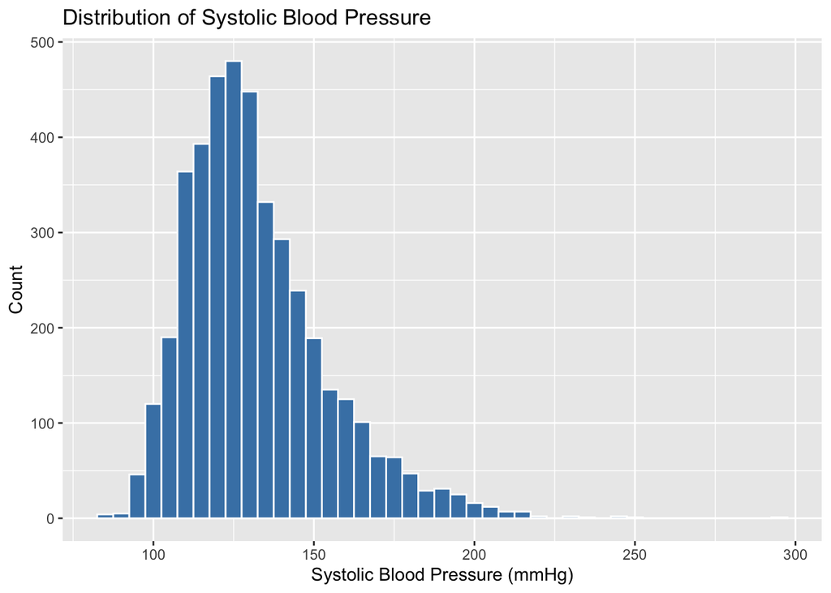

```r
ggplot(framingham, aes(x = sysBP)) +
  geom_histogram(binwidth = 5, fill = "steelblue", color = "white") +
  labs(x = "Systolic Blood Pressure (mmHg)", y = "Count",
       title = "Distribution of Systolic Blood Pressure")
```

### 8.2.2 Continuous Variables: Density Plots

A density plot is a smoothed histogram. It is better than a histogram for overlaying multiple groups because lines are easier to compare than bars.

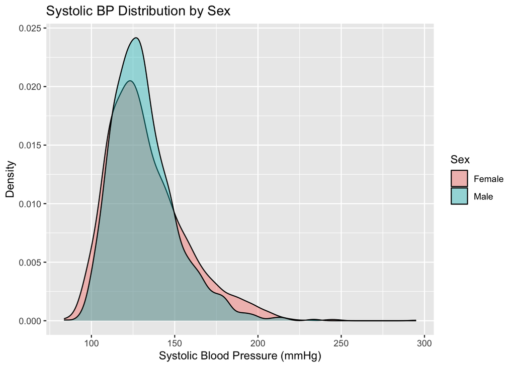

```r
ggplot(framingham, aes(x = sysBP, fill = male)) +
  geom_density(alpha = 0.4) +
  labs(x = "Systolic Blood Pressure (mmHg)", y = "Density",
       fill = "Sex",
       title = "Systolic BP Distribution by Sex")
```

### 8.2.3 Categorical Variables: Bar Charts

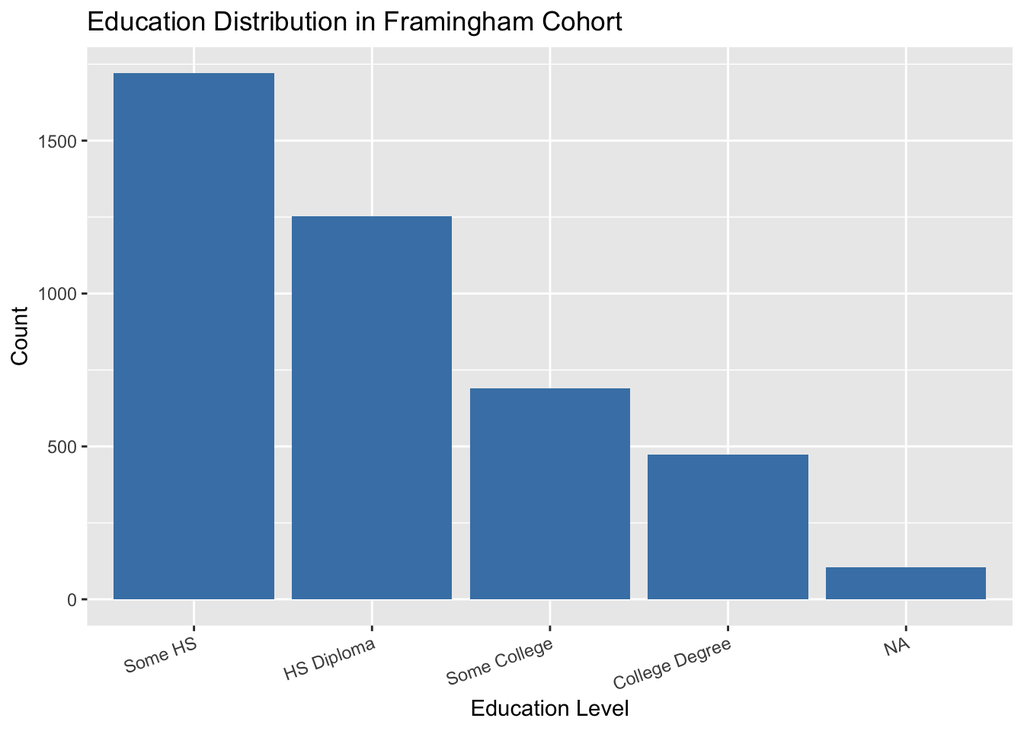

```r
ggplot(framingham, aes(x = education)) +
  geom_bar(fill = "steelblue") +
  labs(x = "Education Level", y = "Count",
       title = "Education Distribution in Framingham Cohort") +
  theme(axis.text.x = element_text(angle = 20, hjust = 1))
```

To plot proportions rather than counts, compute them first with `dplyr` and use `geom_col()`:

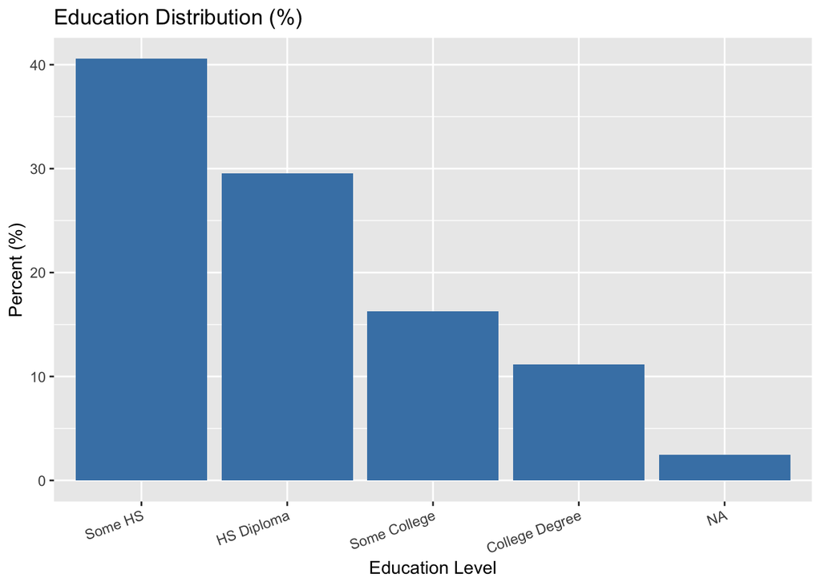

```r
framingham |>
  count(education) |>
  mutate(pct = n / sum(n) * 100) |>
  ggplot(aes(x = education, y = pct)) +
  geom_col(fill = "steelblue") +
  labs(x = "Education Level", y = "Percent (%)",
       title = "Education Distribution (%)") +
  theme(axis.text.x = element_text(angle = 20, hjust = 1))
```

## 8.3 Visualizing Covariation

### 8.3.1 Continuous + Categorical: Boxplots

Boxplots show the median, IQR, and outliers compactly. They are ideal for comparing a continuous variable across groups.

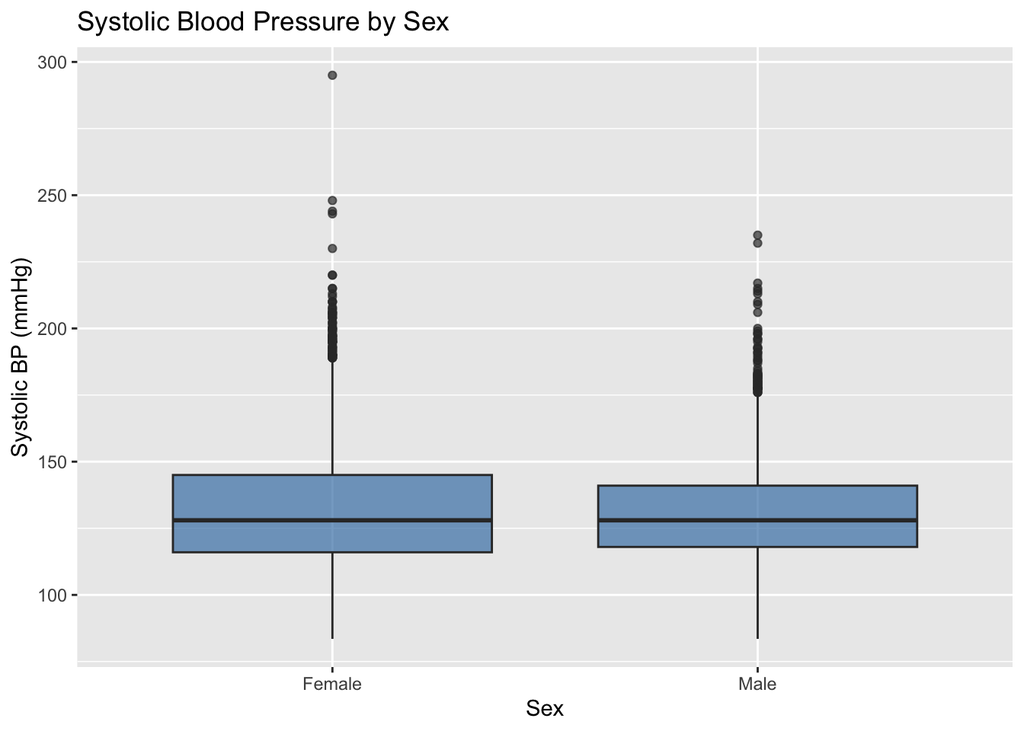

```r
ggplot(framingham, aes(x = male, y = sysBP)) +
  geom_boxplot(fill = "steelblue", alpha = 0.7) +
  labs(x = "Sex", y = "Systolic BP (mmHg)",
       title = "Systolic Blood Pressure by Sex")
```

When you have many groups, order them by the median to make comparisons easier:

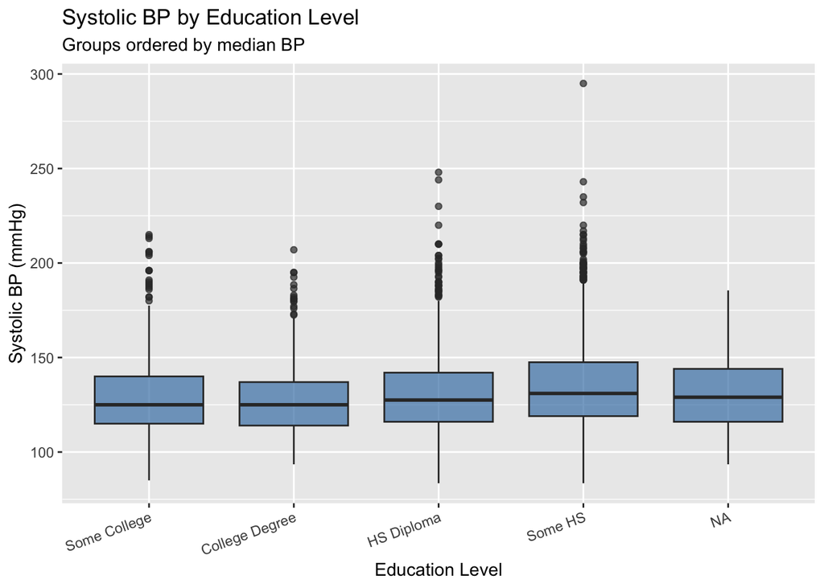

```r
ggplot(framingham, aes(x = reorder(education, sysBP, FUN = median),
                       y = sysBP)) +
  geom_boxplot(fill = "steelblue", alpha = 0.7) +
  labs(x = "Education Level",
       y = "Systolic BP (mmHg)",
       title = "Systolic BP by Education Level",
       subtitle = "Groups ordered by median BP") +
  theme(axis.text.x = element_text(angle = 20, hjust = 1))
```

### 8.3.2 Continuous + Categorical: Violin Plots

A violin plot shows the full distribution shape, not just the summary statistics. Combine with a boxplot overlay for the best of both:

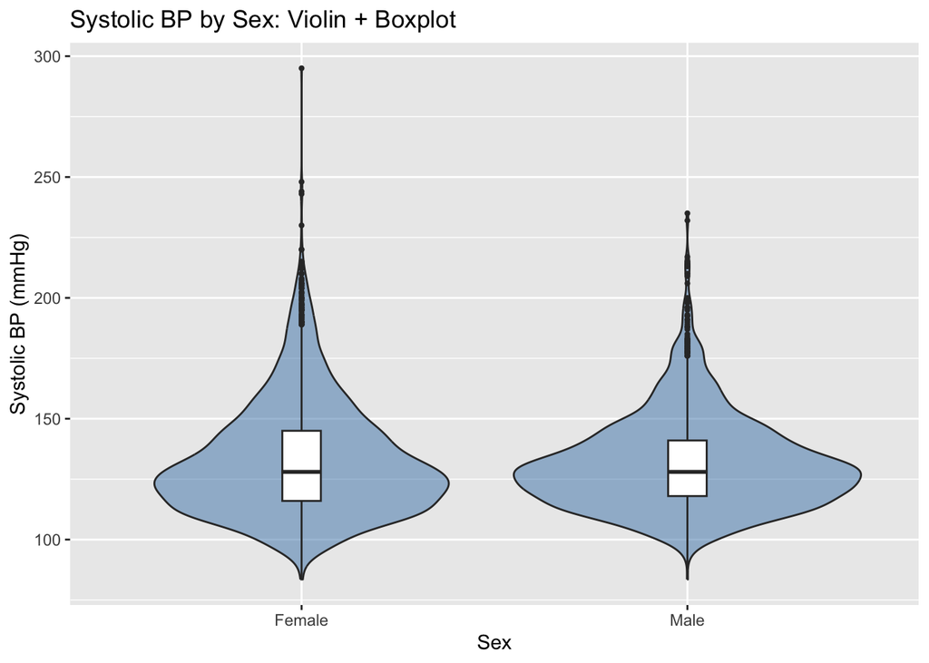

```r
ggplot(framingham, aes(x = male, y = sysBP)) +
  geom_violin(fill = "steelblue", alpha = 0.5) +
  geom_boxplot(width = 0.1, fill = "white", outlier.size = 0.8) +
  labs(x = "Sex", y = "Systolic BP (mmHg)",
       title = "Systolic BP by Sex: Violin + Boxplot")
```

### 8.3.3 Two Continuous Variables: Scatterplots

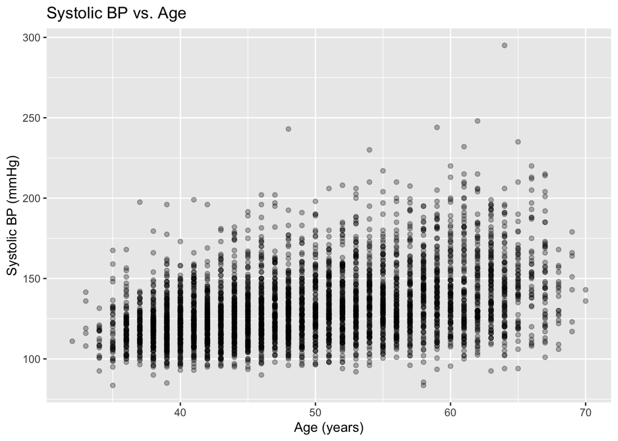

```r
ggplot(framingham, aes(x = age, y = sysBP)) +
  geom_point(alpha = 0.3) +
  labs(x = "Age (years)", y = "Systolic BP (mmHg)",
       title = "Systolic BP vs. Age")
```

Add a smooth trend line with `geom_smooth()`:

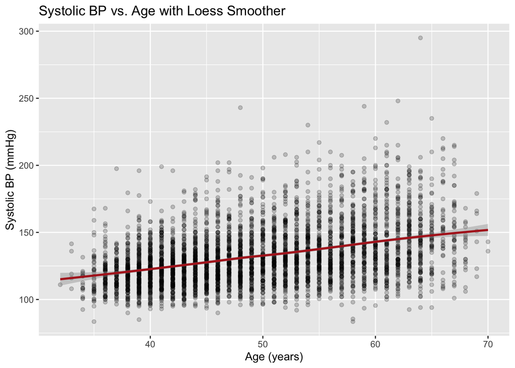

```r
ggplot(framingham, aes(x = age, y = sysBP)) +
  geom_point(alpha = 0.2) +
  geom_smooth(method = "loess", color = "firebrick", se = TRUE) +
  labs(x = "Age (years)", y = "Systolic BP (mmHg)",
       title = "Systolic BP vs. Age with Loess Smoother")
```

Map a third variable to color:

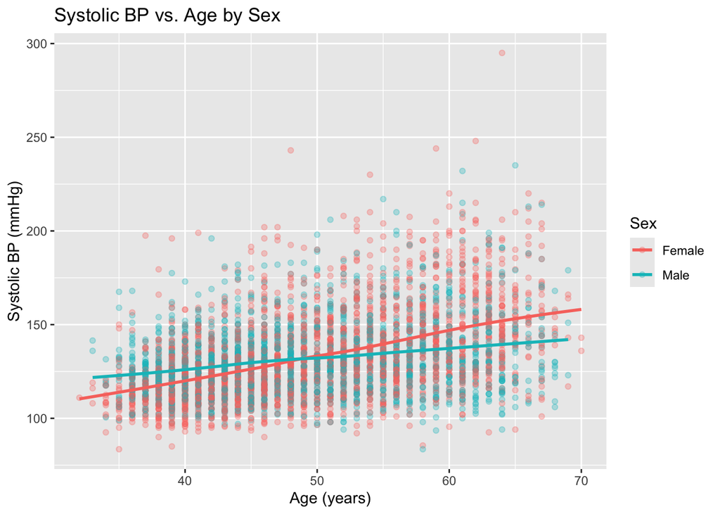

```r
ggplot(framingham, aes(x = age, y = sysBP, color = male)) +
  geom_point(alpha = 0.3) +
  geom_smooth(method = "loess", se = FALSE) +
  labs(x = "Age (years)", y = "Systolic BP (mmHg)",
       color = "Sex",
       title = "Systolic BP vs. Age by Sex")
```

## 8.4 Faceting

Faceting splits a plot into small multiples by a variable — often cleaner than color coding when there are many groups.

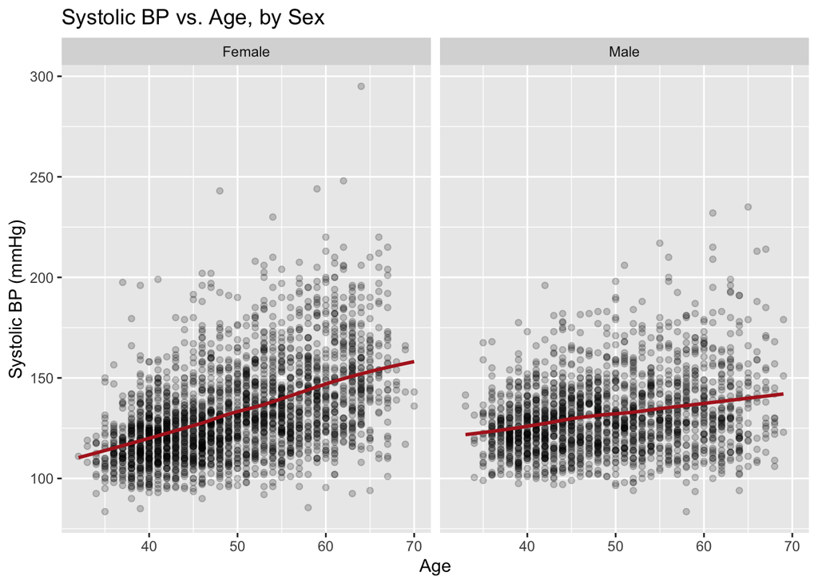

```r
ggplot(framingham, aes(x = age, y = sysBP)) +
  geom_point(alpha = 0.2) +
  geom_smooth(method = "loess", se = FALSE, color = "firebrick") +
  facet_wrap(~ male) +
  labs(x = "Age", y = "Systolic BP (mmHg)",
       title = "Systolic BP vs. Age, by Sex")
```

`facet_grid()` facets on two variables simultaneously:

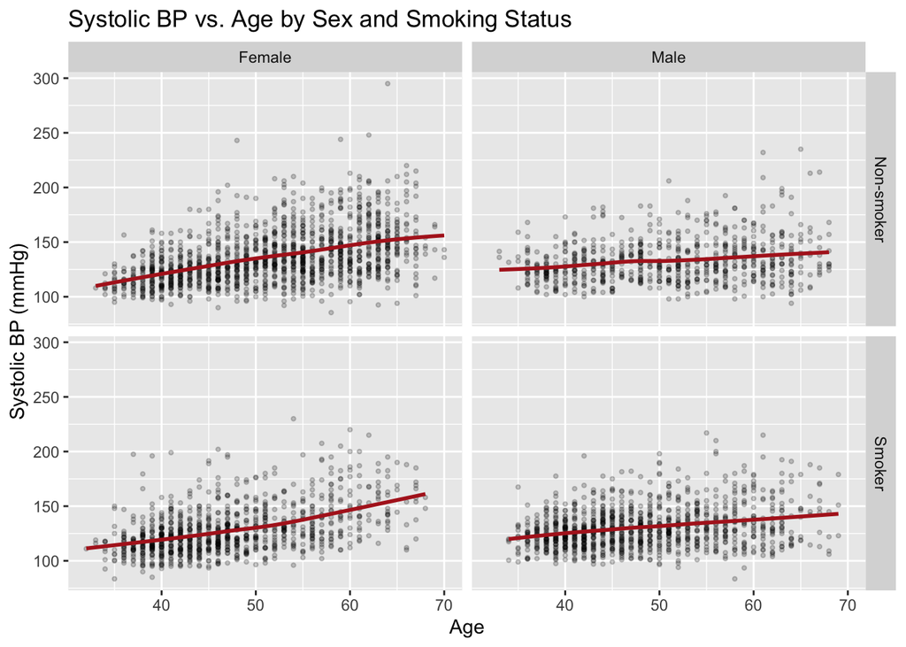

```r
ggplot(framingham, aes(x = age, y = sysBP)) +
  geom_point(alpha = 0.2, size = 0.8) +
  geom_smooth(method = "loess", se = FALSE, color = "firebrick") +
  facet_grid(currentSmoker ~ male) +
  labs(x = "Age", y = "Systolic BP (mmHg)",
       title = "Systolic BP vs. Age by Sex and Smoking Status")
```

## 8.5 Labels and Annotation

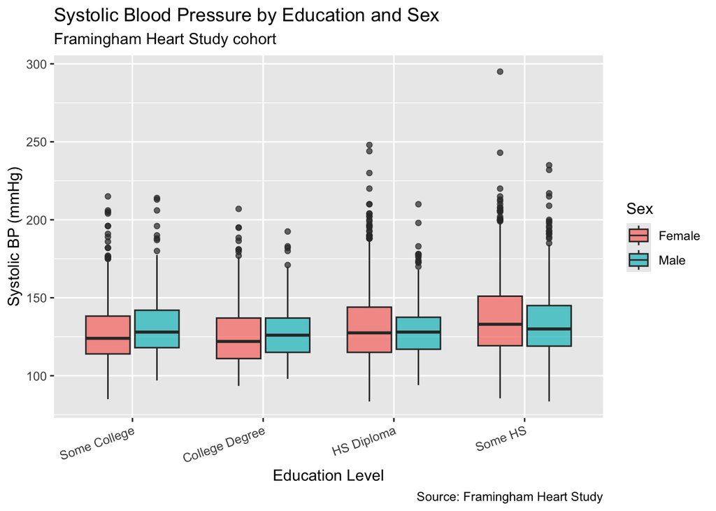

```r
framingham |>
  filter(!is.na(education)) |>
  ggplot(aes(x = reorder(education, sysBP, FUN = median),
                         y = sysBP, fill = male)) +
  geom_boxplot(alpha = 0.7) +
  labs(
    title    = "Systolic Blood Pressure by Education and Sex",
    subtitle = "Framingham Heart Study cohort",
    caption  = "Source: Framingham Heart Study",
    x        = "Education Level",
    y        = "Systolic BP (mmHg)",
    fill     = "Sex"
  ) +
  theme(axis.text.x = element_text(angle = 20, hjust = 1))
```

Add horizontal or vertical reference lines to mark thresholds:

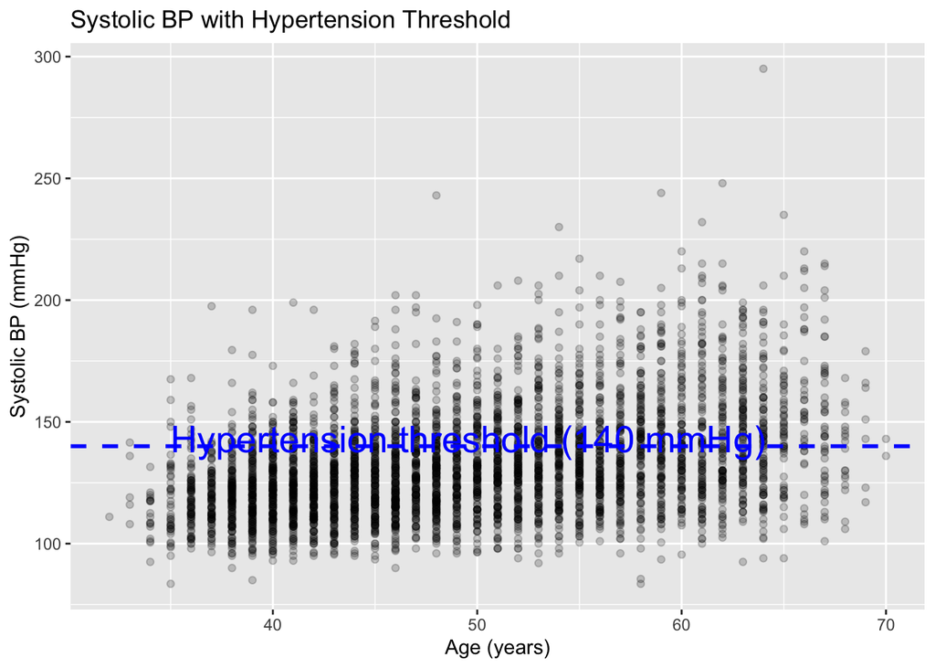

```r
ggplot(framingham, aes(x = age, y = sysBP)) +
  geom_point(alpha = 0.2) +
  geom_hline(yintercept = 140, color = "blue",
             linewidth = 1, linetype = "dashed") +
  annotate("text", x = 35, y = 143,
           label = "Hypertension threshold (140 mmHg)",
           color = "blue", hjust = 0, size = 7) +
  labs(x = "Age (years)", y = "Systolic BP (mmHg)",
       title = "Systolic BP with Hypertension Threshold")
```

## 8.6 Scales and Themes

Color scales: use ColorBrewer palettes for categorical variables and viridis for continuous color, both of which are colorblind-friendly:

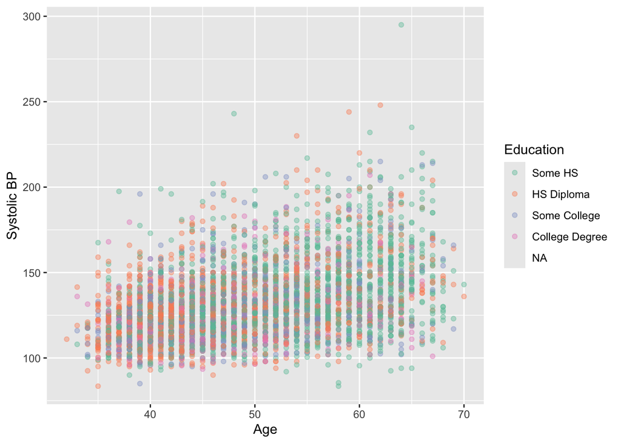

```r
ggplot(framingham, aes(x = age, y = sysBP, color = education)) +
  geom_point(alpha = 0.4) +
  scale_color_brewer(palette = "Set2") +
  labs(x = "Age", y = "Systolic BP", color = "Education")
```

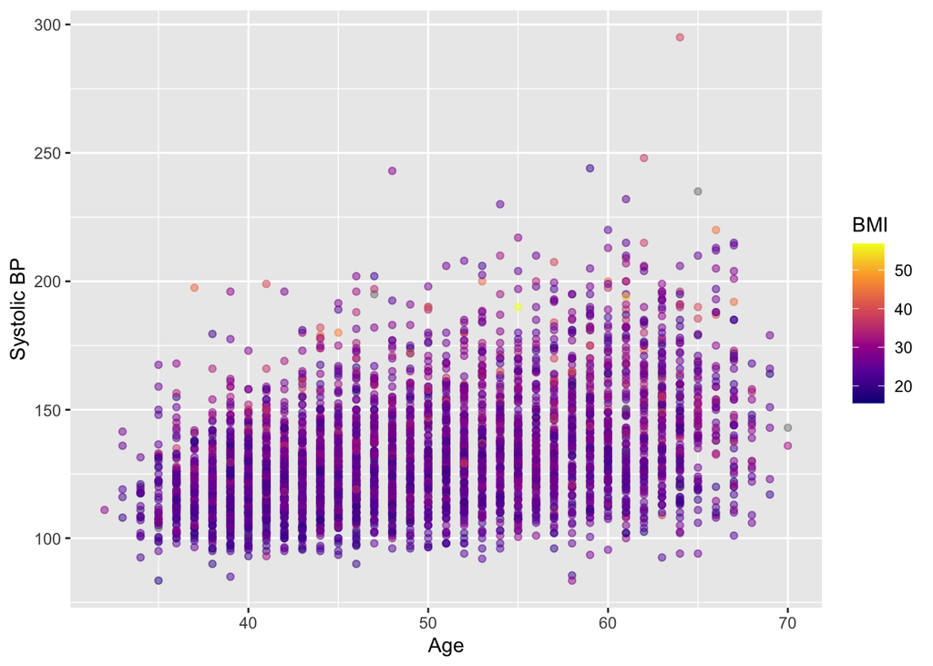

```r
ggplot(framingham, aes(x = age, y = sysBP, color = BMI)) +
  geom_point(alpha = 0.5) +
  scale_color_viridis_c(option = "plasma") +
  labs(x = "Age", y = "Systolic BP", color = "BMI")
```

Themes control all non-data elements: background, grid lines, fonts, and text size:

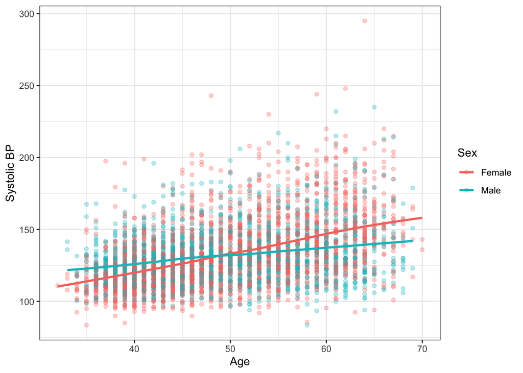

```r
base <- ggplot(framingham, aes(x = age, y = sysBP, color = male)) +
  geom_point(alpha = 0.3) +
  geom_smooth(method = "loess", se = FALSE) +
  labs(x = "Age", y = "Systolic BP", color = "Sex")

base + theme_bw()
```

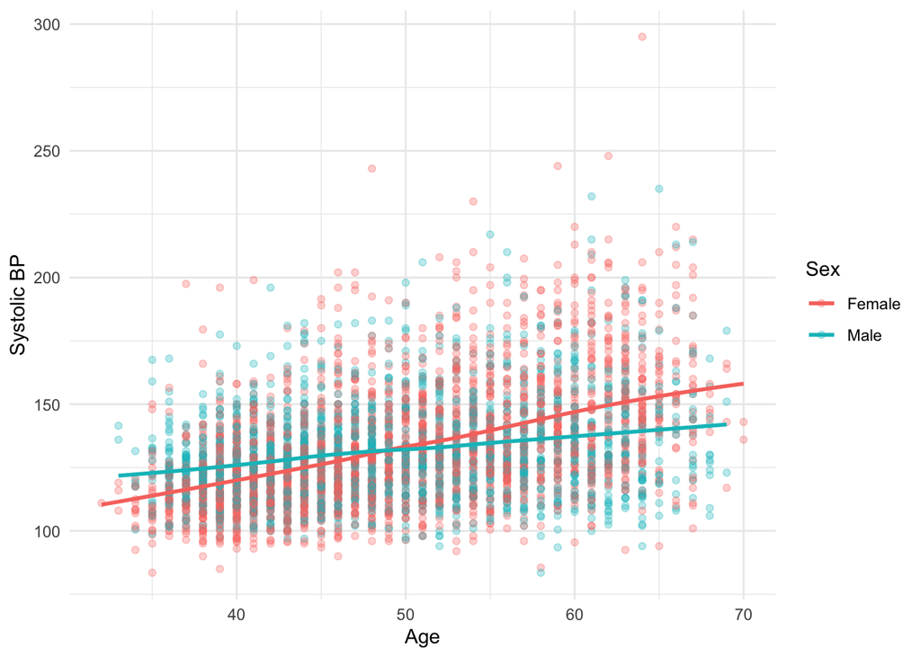

```r
base + theme_minimal()
```

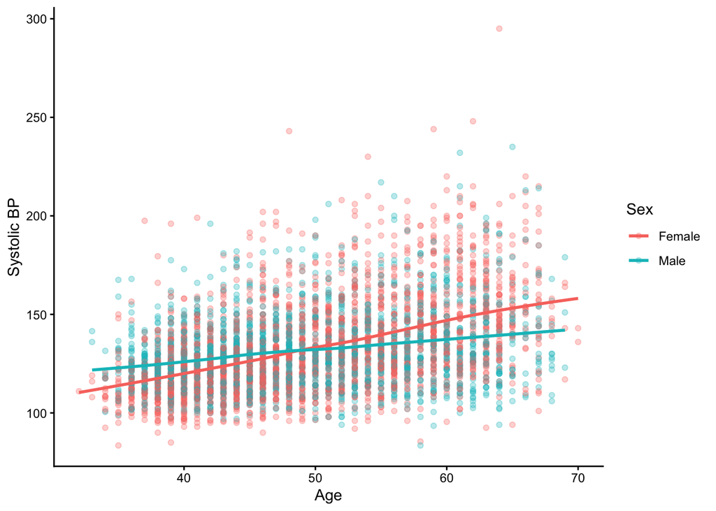

```r
base + theme_classic()
```